# supertues

@tomstafford

Original: 4 March 2020, revised: 12 May 2020

## Bang for your buck? Candidate Ad spend in the Democractic primary correlated with votes and delegates

### Research Question

The “Super Tuesday” of the Democratic Primary, sees a field of candidates with a wide range of advertising budgets, compete for votes across 16 US states on a single. It affords us the chance to ask: did the people who spent the most money on advertising get the most votes?

### Data Origins

Total ad spend by 4th of March 2020, as reported by [CNN](https://edition.cnn.com/2020/03/02/politics/super-tuesday-ad-spending/index.html)

The number of delegates and votes, as reported by [Wikipedia](https://en.wikipedia.org/wiki/Results_of_the_2020_Democratic_Party_presidential_primaries#Super_Tuesday) by the end of 4th of March - “Super Tuesday”.

I could have made this neater by pulling and merging these two data sets automatically, but instead I just copied and pasted them into a single spreadsheet.

```r
df =read.csv('supertuesday.csv') # load data
```

### Data Preparation

```r
#tidying, changing type
df$delegates <- as.numeric(as.character(df$delegates1546))
df$votes  <- as.numeric(as.character(df$votes1546))

#tidying, remove all except variables we need
df <- df %>% select (-c(delegates0820,votes0820,delegates1546,votes1546))

print(df) #we can show all data, since this is a small data set
```

```
##          candidates spend delegates   votes
## 1 Michael Bloomberg 560.0        64 1573388
## 2        Tom Steyer 210.0         0  194646
## 3      Donald Trump  60.0        NA      NA
## 4    Bernie Sanders  55.0       395 3442670
## 5    Pete Buttigieg  36.0        26  594202
## 6  Elizabeth Warren  27.0        47 3442670
## 7     Amy Klobuchar  17.0         7  369504
## 8         Joe Biden  16.0       497 4365361
## 9     Tulsi Gabbard   5.5         2   92772
```

### Visulisation 1: Spend v Delegates

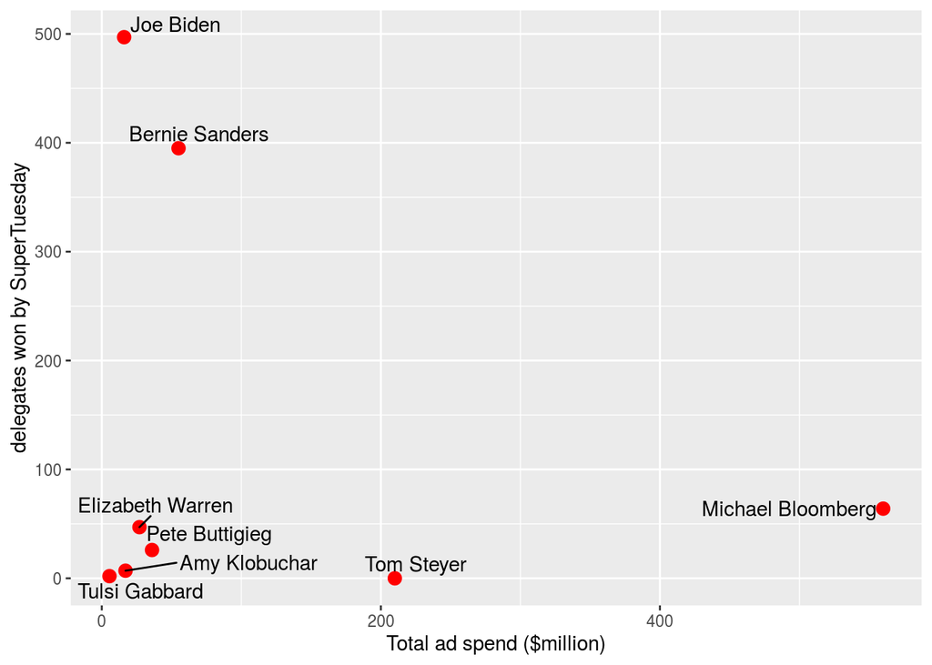

```r
p <- ggplot(data = df, mapping = aes(x = spend, y=delegates,label = candidates))
p + geom_point(color='red',size=3) +
  labs(x = "Total ad spend ($million)", y = "delegates won by SuperTuesday") +
  geom_text_repel()
  xlim(0,750)

#save output
ggsave('delegates.png')
```

It looks safe to conclude there is no strong relationship

### Visualisation 2: Spend v Votes

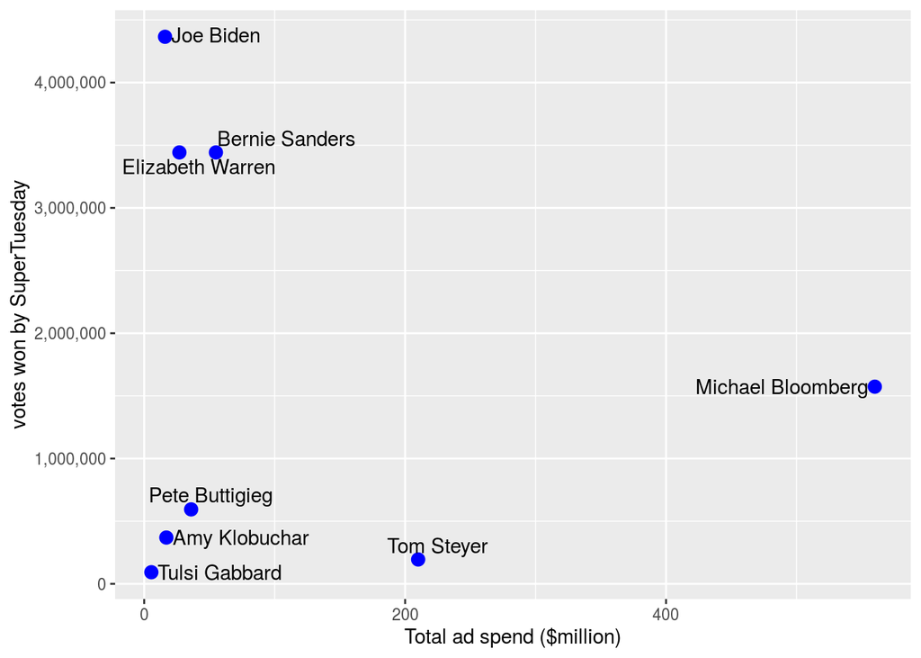

```r
p <- ggplot(data = df, mapping = aes(x = spend, y=votes, label=candidates))
p + geom_point(color='blue',size=3) +
  labs(x = "Total ad spend ($million)", y = "votes won by SuperTuesday") +
  geom_text_repel() +
  scale_y_continuous(labels = scales::comma)

#save output
ggsave('votes.png')
```

Again, it is safe to conclude there is no strong relationship

### Visualisation 3: Price for votes

Let’s work out how much each candidate payed per vote/delegate (note, this makes the very dubious assumption that with 0 ad spend they would get 0 votes/delegates)

```r
df <- df %>% mutate(per_delegate=(spend*1000000)/delegates,per_vote=(spend*1000000)/votes) %>% drop_na()

print(df)
```

```
##          candidates spend delegates   votes per_delegate    per_vote
## 1 Michael Bloomberg 560.0        64 1573388   8750000.00  355.919837
## 2        Tom Steyer 210.0         0  194646          Inf 1078.881662
## 4    Bernie Sanders  55.0       395 3442670    139240.51   15.975972
## 5    Pete Buttigieg  36.0        26  594202   1384615.38   60.585457
## 6  Elizabeth Warren  27.0        47 3442670    574468.09    7.842750
## 7     Amy Klobuchar  17.0         7  369504   2428571.43   46.007621
## 8         Joe Biden  16.0       497 4365361     32193.16    3.665218
## 9     Tulsi Gabbard   5.5         2   92772   2750000.00   59.285129
```

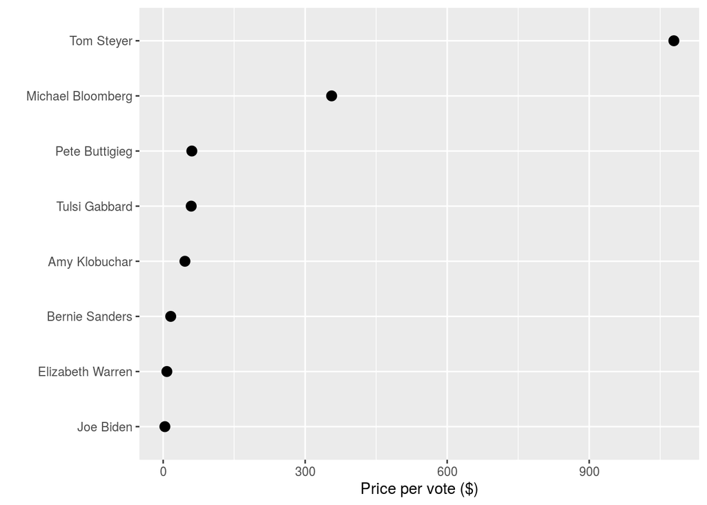

```r
p <- ggplot(data=df,
            mapping=aes(x = per_vote,y=reorder(candidates,per_vote)))

p + geom_point(size=3) +
  labs(x= "Price per vote ($)",y="") +
  scale_x_continuous(labels = scales::comma)

ggsave('pervote.png')
```

### Summary, Discussion

Enjoy discussion of this analysis around the twitter [thread here](https://twitter.com/tomstafford/status/1235136079226966016)

Caveat #1: Initial graphing done while results were still coming in, so the actual figures changed (but the general pattern held).

Caveat #2: [Apparently Bloomberg’s ads were terrible](https://twitter.com/broonstunes/status/1235209867079626753) so better ads might have had an effect.

Caveat #3: Also, primary voters are almost by defintion high engagement, [so this doesn’t test the case of influencing decisions from low-engagement voters](https://twitter.com/broonstunes/status/1235209867079626753)

Caveat #4: [Maybe we should think of Bloomberg’s spend as a hedge against the collapse of the Biden campaign](https://twitter.com/PavelDAtanasov/status/1235224962920828929)

Caveat #5: Maybe Bloomberg was buying something other than votes (e.g. press)

Caveat #6: [Maybe it was effective, since he overtook Biden in the polls at one point (from a lower base)](https://twitter.com/mathewe/status/1235168728062529536)

Caveat #7: Bloomberg’s campaign stalled after disappointing debate performance, [“there’s only so much advertising can do with a bad product”](https://twitter.com/mathewe/status/1235168728062529536)

### Colophon

Normally I’d do this with Python, but I was inspired by Kieran Healy’s book to use R. It’s a great book:

- Healy, K. (2018). [Data visualization: a practical introduction](https://socviz.co/). Princeton University Press.
- This page was useful in publishing to github [How to publish project online?](https://rpubs.com/cathydatascience/518692) by Cathy Gao, August 7, 2019. Thanks Cathy!

Repo for this analysis (the markdown file which generated this page, data and plot files) is here: github.com/tomstafford/supertues